# STAT 331 Portfolio

Author

Pablo Nguyen

**My Grade:** I believe my grade equivalent to course work evidenced below to be an A.

**Learning Objective Evidence:** In the code chunks below, provide code from a Lab or Challenge assignment where you believe you have demonstrated proficiency with the specified learning target. Be sure to specify **where** the code came from (e.g., Lab 4 Question 2).

## Working with Data

**WD-1: I can import data from a *variety* of formats (e.g., csv, xlsx, txt, etc.).**

- `csv`.  
  Lab 2 Question 1

```r
surveys <- read_csv(file =  here( "week2" , "labs" , "surveys.csv" ))
```

- `xlsx`

  Practice Activity 4 Question 1

```r
library(readxl)
library(tidyverse)

military <- read_xlsx(here::here("data", "gov_spending_per_capita.xlsx"),
                      sheet = "Share of Govt. spending",
                      skip = 6, n_max =192)
```

- `txt`

  Practice Activity 5.2 Setup

```r
message <- read_csv(here::here("data", "scrambled_message.txt")
                      )
```

**WD-2: I can select necessary columns from a dataset.** Lab 3 Question 9

```r
demographics_information <- hiphop_clean |>
  distinct( subj , .keep_all = TRUE) |>
  select(sex:ethnic, ethnic1)
```

**WD-3: I can filter rows from a dataframe for a *variety* of data types (e.g., numeric, integer, character, factor, date).**

- numeric

  Lab 3 Question 11

```r
hiphop_clean |>
  group_by(word) |>
  filter(age < 20) |>
  summarize(mean_word_score = mean(as.numeric(familiarity))) |>
  slice_max(order_by = mean_word_score)
```

- character – specifically a string

Lab 9 5.8

```r
Allen_names <- StateNames_A |>
  filter(Name %in% c("Allen", "Allan", "Alan"))
```

- factor

  Lab 3 Question 13: “Male” and “ethnic1” were Factors

```r
hiphop_clean |>
  group_by(word) |>
  filter(sex == "Male", ethnic1 == "white", age > 30) |>
  summarize(mean_word_score = mean(as.numeric(familiarity))) |>
  slice_max(order_by = mean_word_score)
```

- date

  Practice Activity 5.1 (Lubridate) Question 2

```r
suspects <- suspects %>%
  filter(!wday(Time.Spotted, label = TRUE, abbr = FALSE) %in%
           c("Tuesday" , "Thursday"))
```

**WD-4: I can modify existing variables and create new variables in a dataframe for a *variety* of data types (e.g., numeric, integer, character, factor, date).**

- numeric

  PA 3, Question 6

```r
colleges_clean <- colleges_clean |>
  mutate(TUITION_DIFF = TUITIONFEE_OUT - TUITIONFEE_IN)
```

- character – specifically a string

  Lab 3 Question 7

```r
hiphop_clean <- hiphop_clean |>
  mutate(ethnic1 = if_else(condition = ethnic == "white" ,true = "white" ,
                           false = "nonwhite"),
         ethnic1 = as.factor(ethnic1))
```

- factor

  Lab 3 Question 5 (revision)

  “.fns = as.factor” was deprecated

```r
hiphop_clean <- hiphop |>
  select(-c(numPreferredArtists , numOverallArtists)) |>
  mutate(
    across( .cols = c(word , subj , sex , ethnic , familiarity , fam1 , jayz ,
                  jayz1 , barkley , boondocks , boondocks1 , monique , bieber) ,
           ~as.factor(.x))
  )
```

- date

  PA 5, Question 1

```r
suspects <- suspects %>%
  mutate(Time.Spotted = ymd_hms(Time.Spotted),
         Time.Spotted = force_tz(Time.Spotted,
                                 tzone = "America/Los_Angeles")
         )
```

**WD-5: I can use mutating joins to combine multiple dataframes.**

- `left_join()`
- `right_join()`
- `inner_join()`

  Preview Activity 4.3.1

```r
inner_join(prof_info, prof_course)
```

- `full_join()`

  Preview Activity 4.3.2

```r
full_join(prof_info, prof_course)
```

**WD-6: I can use filtering joins to filter rows from a dataframe.**

- `semi_join()`

  Lab 4 Data Cleaning (2)

```r
avocado_clean_major_region <- avocado_clean |>
  semi_join( super_regions, by = "region")
```

- `anti_join()`

  Lab 4 Data Cleaning (2)

```r
avocado_clean_subregion <- avocado_clean |>
  anti_join(super_regions, by = "region")
```

**WD-7: I can pivot dataframes from long to wide and visa versa**

- `pivot_longer()`

  Lab 4 Question 7

```r
avocado_ratios <- four_cities |>
  pivot_longer(cols = c("Small_Hass":"Extra_Large_Hass"),
               names_to = "Avocado_Type",
               values_to = "Total") |>
  group_by(region,Avocado_Type, type) |>
  summarise(total = sum(Total))
```

- `pivot_wider()`

  Lab 9 3.1 (revised, using values_fill = 0)

```r
Allison_stats <- StateNames_A |>
  filter(Name == "Allison") |>
  group_by(State, Sex) |>
  summarize(count_total = sum(Count), .groups = "drop") |>
  pivot_wider(names_from = Sex, values_from = count_total, values_fill = 0)
Allison_stats
```

## Reproducibility

**R-1: I can create professional looking, reproducible analyses using RStudio projects, Quarto documents, and the here package.**

**R-2: I can write well documented and tidy code.**

- Example 1

  Lab 5 Question 3.3 (revision)

  Axis titles were redundant, code was unclear

```r
surveys |>
  mutate(weekday = factor(lubridate::wday(x = date, label = TRUE),
                          levels = day_levels)) |> #order factors mon-sun
  filter(!is.na(date)) |>
  #collapse Weekends and Weekdays
  mutate(weekday = fct_collapse(.f = weekday,
                              "Weekday" = c("Mon", "Tue", "Wed", "Thu", "Fri"),
                              "Weekend" = c( "Sat", "Sun"))) |>
  ggplot(mapping = aes(x = weekday)) +
  geom_bar() +
  labs(title = "Number of Captured Rodents by Weekday vs Weekend", y = NULL,
       x = NULL)
```

- Example 2

  Lab 3 Question 7

```r
hiphop_clean <- hiphop_clean |>
  mutate(ethnic1 = if_else(condition = ethnic == "white" ,true = "white" ,
                           false = "nonwhite"),
         ethnic1 = as.factor(ethnic1))
```

**R-3: I can write robust programs that are resistant to changes in inputs.**

- Example 1

  Lab 3 Question 5 (revision)

```r
hiphop_clean <- hiphop |>
  select(-c(numPreferredArtists , numOverallArtists)) |>
  mutate(
    across( .cols = c(word , subj , sex , ethnic , familiarity , fam1 , jayz ,
                  jayz1 , barkley , boondocks , boondocks1 , monique , bieber) ,
           ~as.factor(.x))
  )
```

- Example 2

  Lab 3 Question 11

```r
hiphop_clean |>
  group_by(word) |>
  filter(age < 20) |>
  summarize(mean_word_score = mean(as.numeric(familiarity))) |>
  slice_max(order_by = mean_word_score)
```

## Data Visualization & Summarization

**DVS-1: I can create visualizations for a *variety* of variable types (e.g., numeric, character, factor, date)**

- numeric variables

  Lab 2 Question 6

```r
ggplot(data = surveys , mapping = aes(x = weight , y = hindfoot_length)) +
  geom_jitter(alpha = .2)
```

- numeric variables and categorical variables

  Lab 7 2.2

```r
#plot data
plot_data |>
  ggplot(mapping = aes(x = year, fill = trip)) +
  geom_bar() +
  facet_wrap(~section) +
  labs(title = "Frequency of NAs by Year, Trip, And Section", x = "Year",
       y = NULL, fill = "Trip Number")
```

- categorical variables

  Lab 3 Question 10

```r
ggplot(data = demographics_information, aes(x = sex)) +
  geom_bar() +
  labs(x = "Sex (Male vs Female)", y = ("Count") ,
       title = "Count of Males Vs Females") +
  theme(legend.position = "none")
```

- dates

  Lab 5 Question 3.3 (revision)

```r
surveys |>
  mutate(weekday = factor(lubridate::wday(x = date, label = TRUE),
                          levels = day_levels)) |> #order factors mon-sun
  filter(!is.na(date)) |>
  #collapse Weekends and Weekdays
  mutate(weekday = fct_collapse(.f = weekday,
                              "Weekday" = c("Mon", "Tue", "Wed", "Thu", "Fri"),
                              "Weekend" = c( "Sat", "Sun"))) |>
  ggplot(mapping = aes(x = weekday)) +
  geom_bar() +
  labs(title = "Number of Captured Rodents by Weekday vs Weekend", y = NULL,
       x = "Weekday vs Weekend")
```

**DVS-2: I use plot modifications to make my visualization clear to the reader.**

- Example 1

  Lab 5 Question 2.4

```r
summarized_surveys |>
  ggplot(mapping = aes( x = year, y = mean_weight,
                                          color = fct_reorder2(.f = species,
                                                            .x = mean_weight,
                                                        .y =  mean_weight))) +
  geom_line() +
  labs(title = "Mean Weight(g) Of Species of Rodent by Year", x = "Year",
       y = NULL, color = "Species")
```

- Example 2

  Lab 7 2.2

```r
#plot data
plot_data |>
  ggplot(mapping = aes(x = year, fill = trip)) +
  geom_bar() +
  facet_wrap(~section) +
  labs(title = "Frequency of NAs by Year, Trip, And Section", x = "Year",
       y = NULL, fill = "Trip Number")
```

**DVS-3: I show creativity in my visualizations**

- Example 1

  Lab 4 Question 5

```r
ggplot(data = metros_avocado_data, mapping = aes(x = `Total Volume`,
                                                 y = region)) +
  geom_boxplot() +
  geom_jitter(alpha = .2) +
  labs(y = "Metros", title = "Metros With the Highest Average of Total Volume")
```

- Example 2

  Lab 3 Question 10

```r
ggplot(data = demographics_information, aes(x = age))+
  geom_histogram() +
  facet_wrap(~ sex) +
  labs(x = "Age (years)", y = ("Count") ,
       title = "Histogram of Subject's Ages") +
  theme(legend.position = "none")
```

**DVS-4: I can calculate numerical summaries of variables.**

- Example 1

  Lab 9 3.1

```r
Allison_stats <- StateNames_A |>
  filter(Name == "Allison") |>
  group_by(State, Sex) |>
  summarize(count_total = sum(Count), .groups = "drop") |>
  pivot_wider(names_from = Sex, values_from = count_total, values_fill = 0)
```

- Example 2

  Lab 5 Question 2.2

```r
summarized_surveys <- surveys |>
  group_by(species, year) |>
  summarize(mean_weight = mean(weight))
```

**DVS-5: I can find summaries of variables across multiple groups.**

- Example 1

  Lab 9 3.1

```r
Allison_stats <- StateNames_A |>
  filter(Name == "Allison") |>
  group_by(State, Sex) |>
  summarize(count_total = sum(Count), .groups = "drop") |>
  pivot_wider(names_from = Sex, values_from = count_total, values_fill = 0)
```

- Example 2 Lab 9 5.9 (revised, using values_fill)

```r
Allen_names_CA_PA <- Allen_names |>
  filter(State == "CA" | State == "PA") |>
  group_by(State, Name) |>
  summarize(Total_Count = sum(Count, na.rm = TRUE), .groups = "drop") |>
  pivot_wider(names_from = Name, values_from = Total_Count, values_fill = 0)
```

**DVS-6: I can create tables which make my summaries clear to the reader.**

- Example 1

  Challenge 9 5.10

```r
Allen_names_CA_PA |>
  #Find the sum of each Row
  mutate(Total = pmap_int(list(Alan, Allan, Allen), sum)) |>
  #find ratio by dividing each count by the total count of each row
  mutate(
    across(.cols = c(Alan:Allen),
           ~ .x/Total)
    ) |>
  subset(select = -c(Total)) |>
  gt() |>
  cols_label(Alan = "Ratio of Alans", Allan = "Ratio of Allans",
             Allen = "Ratio of Allens") |>
  fmt_percent(columns = 2:4, decimals = 2)
```

- Example 2

Challenge 9 3.1

```r
Allison_stats <- StateNames_A |>
  filter(Name == "Allison") |>
  group_by(State, Sex) |>
  summarize(count_total = sum(Count), .groups = "drop") |>
  pivot_wider(names_from = Sex, values_from = count_total) |>
  mutate(
    across(.cols = c(F, M),
         ~ case_when(is.na(.x) ~ 0,TRUE ~ .x)
                )) |>
  gt() |>
  cols_label(F = "Female Count", M = "Male Count") |>
  tab_header(
    title = "Number of Allisons born by State",
    subtitle = "Seperated by Female and Male"
  )
```

**DVS-7: I show creativity in my tables.**

- Example 1 Challenge 9 3.1

```r
Allison_stats <- StateNames_A |>
  filter(Name == "Allison") |>
  group_by(State, Sex) |>
  summarize(count_total = sum(Count), .groups = "drop") |>
  pivot_wider(names_from = Sex, values_from = count_total, values_fill = 0) |>
  gt() |>
  cols_label(F = "Female Count", M = "Male Count") |>
  tab_header(
    title = "Number of Allisons born by State",
    subtitle = "Seperated by Female and Male"
  )
```

- Example 2 Challenge 9 5.10

```r
Allen_names_CA_PA |>
  #Find the sum of each Row
  mutate(Total = pmap_int(list(Alan, Allan, Allen), sum)) |>
  #find ratio by dividing each count by the total count of each row
  mutate(
    across(.cols = c(Alan:Allen),
           ~ .x/Total)
    ) |>
  subset(select = -c(Total)) |>
  gt() |>
  cols_label(Alan = "Ratio of Alans", Allan = "Ratio of Allans",
             Allen = "Ratio of Allens") |>
  fmt_percent(columns = 2:4, decimals = 2)
```

## Program Efficiency

**PE-1: I can write concise code which does not repeat itself.**

- using a single function call

  PA3 Part 2

```r
mystery_school <- colleges_clean |>
  filter(REGION == "7", ADM_RATE > median(ADM_RATE), TUITION_DIFF != 0,
         SAT_AVG %% 2 != 0, STABBR != "ID" & STABBR != "MT",
         as.numeric(UGDS)/4 < 1000/ADM_RATE) |>
  arrange(TUITIONFEE_IN,TUITIONFEE_OUT)
```

- `across()`

  Lab 3 Question 5 (revision)

```r
hiphop_clean <- hiphop |>
  select(-c(numPreferredArtists , numOverallArtists)) |>
  mutate(
    across( .cols = c(word , subj , sex , ethnic , familiarity , fam1 , jayz ,
                  jayz1 , barkley , boondocks , boondocks1 , monique , bieber) ,
           ~as.factor(.x))
  )
```

- `map()` functions Lab 8 step 4

```r
1:12 |>
  map_chr( ~ sing_day(xmas2, .x, Full.Phrase)) |>
  cat()
```

**PE-2: I can write functions to reduce repetition in my code.**

- Example 1 lab 8, pluralize gift

```r
pluralize_gift <- function(gift){

  gift <- case_when( str_detect(gift, pattern = "oo")
    ~ str_replace(string = gift, pattern = "oo", replacement =  "ee"),
    str_detect(gift, pattern = "y$")
    ~ str_replace(string = gift, pattern = "y$", replacement = "ies"),
    TRUE ~ str_c(gift, "s", sep = ""))

return(gift)

}
```

- Example 2 Lab 8, sing day

```r
sing_day <- function(df, day, col){
  stopifnot(is.data.frame(df), is.numeric(day))
  #step 1: set up the intro line
  num_word <- english::ordinal(day)
  intro <-
    glue::glue("On the {num_word} day of Christmas, my true love sent to me:")

  #step 2: sing the gift phrases
  phrases <- df |>
    pull({{col}})
  #put intro, then reverse order of phrases into lyrics
  lyrics <- c(intro, phrases[day:1])
  #step 3: put it all together
  #flatten phrases into 1 string separated by newlines,
  #double newline at the end to seperate days
  output_string <- str_flatten(lyrics, collapse = "\n") |>
    str_c("\n\n")
 return(output_string)
}
```

**PE-3:I can use iteration to reduce repetition in my code.**

- `across()`

  Lab 3 Question 5 (revision)

```r
hiphop_clean <- hiphop |>
  select(-c(numPreferredArtists , numOverallArtists)) |>
  mutate(
    across( .cols = c(word , subj , sex , ethnic , familiarity , fam1 , jayz ,
                  jayz1 , barkley , boondocks , boondocks1 , monique , bieber) ,
           ~as.factor(.x))
  )
```

- `map()` functions (Provide 2 Examples)

  Lab 8 Step 4

```r
1:12 |>
  map_chr( ~ sing_day(xmas2, .x, Full.Phrase)) |>
  cat()
```

Lab 8 step 2, make phrase

```r
xmas2 <- xmas %>%
  mutate(Full.Phrase = pmap_chr(.l = list(Day, Day,
                                          Gift.Item, Verb,
                                          Adjective, Location),
                                .f = make_phrase)
         )
```

**PE-4: I can use modern tools when carrying out my analysis.**

- Example 1

  Lab 4 Question 7

```r
avocado_ratios <- four_cities |>
  pivot_longer(cols = c("Small_Hass":"Extra_Large_Hass"),
               names_to = "Avocado_Type",
               values_to = "Total") |>
  group_by(region,Avocado_Type, type) |>
  summarise(total = sum(Total))
```

- Example 2

  Lab 3 Question 5 (revision)

```r
hiphop_clean <- hiphop |>
  select(-c(numPreferredArtists , numOverallArtists)) |>
  mutate(
    across( .cols = c(word , subj , sex , ethnic , familiarity , fam1 , jayz ,
                  jayz1 , barkley , boondocks , boondocks1 , monique , bieber) ,
           ~as.factor(.x))
  )
```

## Data Simulation & Modeling

**DSM-1: I can simulate data from a *variety* of probability models.**

- Example 1

  Practice Activity 9.2 catching a con

```r
music_man <- function(n_tromb, n_cor, n_reed){

  trombones <- sum(rnorm(n_tromb, mean = 4.6, sd = .8))
  cornets <- sum(runif(n_cor, min = 1.5, max = 3.5))
  reeds <- sum(rchisq(n_reed, df = 4))

  return(trombones + cornets + reeds)

}
```

- Example 2

  Practice Activity 9.2, Warmup

```r
qunif(p = .95, min = 1.5, max = 3.5)
qnorm(.10, mean = 4.6, sd = .8)
1-pnorm(q = 5, mean = 4.6, sd = .8)
1-pchisq(q = 5, df = 4)
sum(rnorm(n = 100, mean = 4.6, sd = .8)<4)
```

**DSM-2: I can fit a linear regression and extract necessary summary measures.**

- Example 1

  Lab 9 4.4 and 4.6

```r
linear_model <- lm(total_count ~ Year, data = count_by_year)
linear_model |>
  broom::augment() |>
  ggplot(mapping = aes(y = .resid, x = .fitted)) +
  geom_point() +
  labs(title = "Residuals by Fitted Values", y = NULL, x = "Fitted Values")
```

- Example 2

  Practice Activity 9.1

```r
linear_model <- lm(weight_after ~ weight_before, data = dataset)

linear_model |>
  broom::augment() |>
  ggplot(mapping = aes(y = .resid, x = .fitted)) +
  geom_point()
```

## Revising My Thinking

Every Week, I have tried to revise my thinking by resubmitting Labs and Challenges that I did not get full credit on. However, I have been trying to incorporate corrections into new assignments, such as improving with visualizations and slicing to find max values in summaries. Additionally, some of the examples provided are revisions so that they can better show my abilities and attainment of learning objectives.

## Extending My Thinking

I wouldn’t say that I have extended My thinking too often, but I always try to make use of outside sources in my code. For example, in Practice Activity 4, I used the “replace()” function to replace all instances of “..” or “xxx” to NA. Although I forgot to cite the page I found it on, I thought this method was much easier than using mutate() and if_else() and was much easier to read. Additionally, I use outside sources to help with labeling Visualizations, such as in Lab 4 when labeling the visualization of proportion of Avocados sold.

## Peer Support & Collaboration

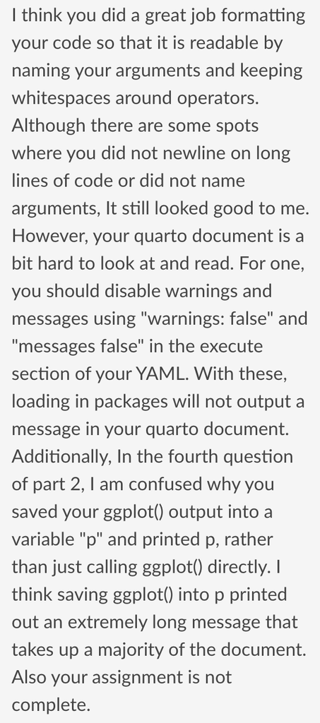